# Baby Names Analysis

Connor Lennard

2023-02-02

## Ask

Choosing the right name for your baby can be a daunting task, as it will stay with them for a lifetime. An analysis of popular baby names can provide useful insights to help parents make an informed decision. By examining the popularity and trends of different names, parents can get a sense of the cultural and societal influences that impact naming choices. This information can also highlight names that have a significant rise or decline in popularity, making it easier for parents to choose a name that is unique, timeless, and reflective of their personal style and values.

An analysis of baby names can also help parents compare names to sibling names. This is especially important for families with multiple children, as they may want to choose names that complement each other or reflect a certain theme. A comparison of sibling names can also help identify common themes and patterns, such as names that start with the same letter or have similar cultural origins. By considering these factors, parents can ensure that their children’s names are not only meaningful and memorable, but also harmonize well with each other, creating a sense of unity within the family.

My task is to compare a target name/sex pair (in this case John/M) to all names of a given sex(F). I will find the most similar names and display them as options to perspective parents.

This will require the following libraries:

- dplyr
- tidyverse
- ggplot2
- data.table
- shiny

## Prepare

I will be using the publicly available data from the Social Security Administration located at https://www.ssa.gov/oact/babynames/names.zip. The data is organized into text files for each year between 1880 and 2021. It includes the name, sex and corresponding count for that year. In each file, the data is sorted by sex and then by count.

A sample head for 2000 is below:

```
##        V1 V2    V3
## 1   Emily  F 25957
## 2  Hannah  F 23085
## 3 Madison  F 19968
## 4  Ashley  F 17997
## 5   Sarah  F 17708
## 6  Alexis  F 17631
```

## Process

I will use R to analyze the full data set for the social security administration. The data is from 1880 to 2021 but I can narrow my focus based on our parameters. This allows me to run the code faster if necessary and focus on specific time frames based on parent needs.

Now that the data has been downloaded, I will load it into a data frame with the columns I need. I’ll add a year column based on the file name and rank the name/sex pairs by count only instead of by sex then count. I will then add a column with the rank of the pair in that year.

The head for the resultant data frame ssa_data is below:

```
##          name sex count year rank
## 1       Jacob   M 34489 2000    1
## 2     Michael   M 32040 2000    2
## 3     Matthew   M 28575 2000    3
## 4      Joshua   M 27538 2000    4
## 5       Emily   F 25957 2000    5
## 6 Christopher   M 24935 2000    6
```

I will now make a data frame of all the unique name/sex pairs in the data set. It will also include the total count across all years. I will order the data frame by count (decreasing) so that I can compare my target name to the top 1000 pair(s). This allows me to compare it to all pairs if necessary or to speed up the data processing by limiting my scope.

```
##      name sex  total
## 1   Jacob   M 454626
## 2 Michael   M 414359
## 3    Emma   F 407258
## 4 William   M 378817
## 5  Olivia   F 375754
## 6   Ethan   M 369083
```

Now that we have all unique name/sex pairs over the years and the total count, I can save to csv files if desired and prepare to analyze.

## Analyze

I decided to give perspective parents a list of the top name/sex pairs that had a similar shape to the given sibling pair. The Social Security data does not have any information about country of origin or history of the name but by finding pairs that had similar trends over time to a pair the parents already like, I will be able to deliver appropriate results.

The main calculation I will be performing is in a function called delta_from_median_vector.

### delta_from_median_vector

**Description:** Takes a data frame of name/sex pairs, counts and years and returns a vector of a specified pair’s deviation from the median in each specific year. Deviation is given in terms of standard deviation.

**Arguments:**

| names | The data frame of name, sex, count, year and rank across the years desired |
| --- | --- |
| v_name | The name to analyze |
| v_sex | The sex to analyze |

**Value:**

**Details:** This function will take a given name/sex pair, find the overall median of the rank and then calculate the difference by standard deviation in each year. This allows pairs with dissimilar counts to be compared numerically as to the general shape of the graph. If the pair does not appear in the data for a specified year, the rank will be set to the max rank in that year plus one and then the difference from the median will be calculated.

I decided to use rank instead of count because rank is more normalized over time. If I used count, every pair would tend to have an upward slope due to increasing population.

```r
# Return a vector of each year's deviation from the total median
delta_from_median_vector <- function(names, v_name, v_sex){
  # Filter the data so it's only for the pair specified
  filtered_list <- names %>%
    filter(name==v_name & sex==v_sex)

  #Find the median count
  med <- summarize(filtered_list, m = median(rank)) %>%
        pull(m)
  std <- summarize(filtered_list, s = sd(rank)) %>%
    pull(s)

  med_deltas <- data.frame()
  for (i in params$begin_year:params$end_year){
    #filter for only the current year's row
    #should return either one or zero rows
    year_list <- filtered_list[filtered_list$year==i,]
    #If the list has more then 0 rows, we have a rank for that year and can
    #evaluate the difference from median
    if(nrow(year_list)>0){
      med_deltas <- rbind(med_deltas, (year_list[1,5]-med)/std)
    }

    #If it has zero rows, that pair did not appear on the SSA's data for that
    #that year. Set the rank to the max rank that year+1 and evaluate
    else{
      max_rank <- nrow(filter(names, year==i))
      med_deltas <- rbind(med_deltas, (max_rank+1L-med)/std)
    }
  }

  return (med_deltas)
}
```

### Find the Closest Names

Now I will find the delta vector for my target name/sex pair. I will then iterate through the list of unique pairs and find the delta vectors. I fill a data frame called result_list with the compared pairs and a measure of the sameness to the target pair. That is just the sum of the differences of each year between the two pairs.

The delta vectors should have the max rank for any years that the pair does not appear but I have error handling just in case. If there are any issues, the program will drop that pair from comparison.

The result_list data frame is ordered by difference (increasing).

```r
#Find the list of the target name/sex pair's deviation from the median
target_name_delta <- delta_from_median_vector(ssa_data, params$target_name, params$target_sex)

#new data frame for the result after the for loop
result_list <- data.frame()
#iterate through each name/sex pair and find the delta number.
#add to a data frame with name, sex and delta number
last_percent <- -1
for(i in 1:min(nrow(unique_names),params$num_names)){
  #percent complete print out
  if(params$display_progress){
    percent <- round(i/min(nrow(unique_names),params$num_names)*100)
    if(percent>last_percent){
      print(paste(percent,"% completed"))
      last_percent <- percent
    }

  }

  #error handling for name/sex pairs that do not have a rank every year.
  tryCatch(
    {
      name_i <- unique_names[i,1]
      sex_i <- unique_names[i,2]
      delta_i <- delta_from_median_vector(ssa_data, name_i, sex_i)
      diff_i <- sum(abs(target_name_delta - delta_i))
      result_list <- rbind(result_list, c(name_i, sex_i, as.double(diff_i)))
    },
    error=function(cond){
      #Should not happen with corrected delta_from_median_vector function
      print(paste("Dropping ",name_i,sep=""))
    }
  )
}
colnames(result_list) <- c("name", "sex", "difference")
result_list <- result_list[order(as.double(result_list$difference)),]
```

This is the head of the resultant list. I can check the function worked by verifying that John/M is the first item with a difference of 0. I will not display this going forward.

```
##       name sex       difference
## 25    John   M                0
## 398 Dakota   M 4.00381292254503
## 328  Peter   M 4.17733658806467
## 505  Kiara   F 5.05664900353318
## 42  Hannah   F 5.13504342211635
## 193   Mary   F 5.17401743555505
## 964   Rosa   F 5.24118817597276
## 751 Philip   M 5.46227325470012
## 445   Hope   F  5.5510965580809
## 940   Anne   F 5.70132767106452
## 419  Laura   F 5.96489879605899
```

## Share

I now have a list of names ordered by similarity to John/M. I’ll filter it by F and will display the head below along of the line graphs.

```
##        name sex       difference
## 1     Kiara   F 5.05664900353318
## 2    Hannah   F 5.13504342211635
## 3      Mary   F 5.17401743555505
## 4      Rosa   F 5.24118817597276
## 5      Hope   F  5.5510965580809
## 6      Anne   F 5.70132767106452
## 7     Laura   F 5.96489879605899
## 8       Ana   F 6.37683420414454
## 9  Carolina   F 6.56034577171299
## 10    Maria   F 6.65064062358688
```

### John/M Rank Trend from 2000 to 2021

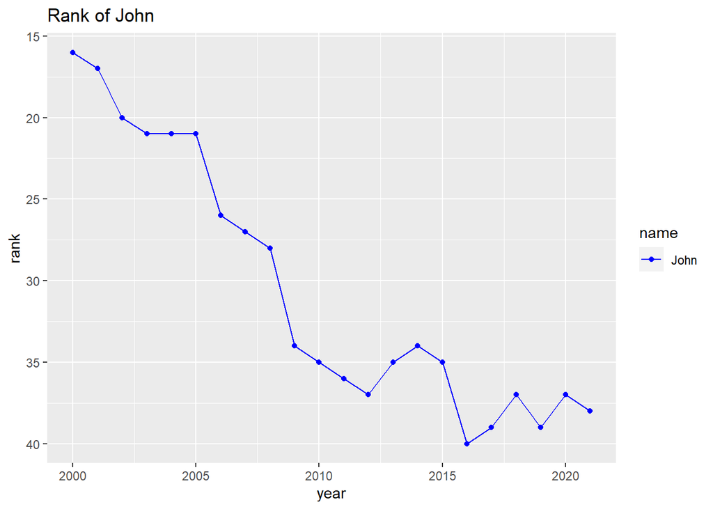

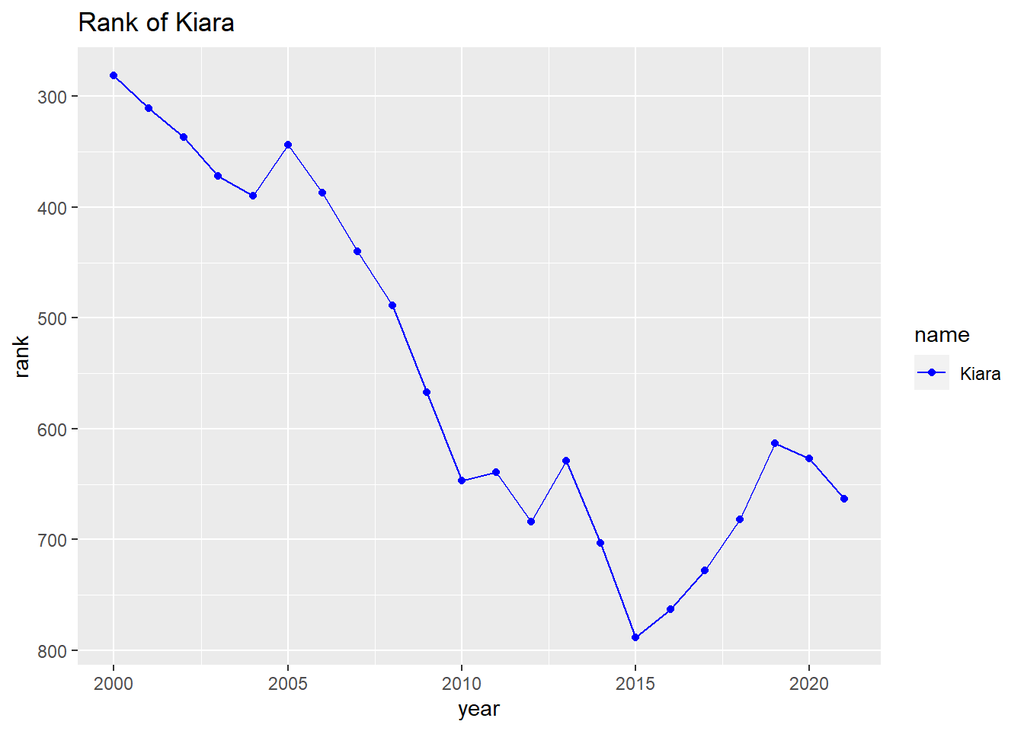

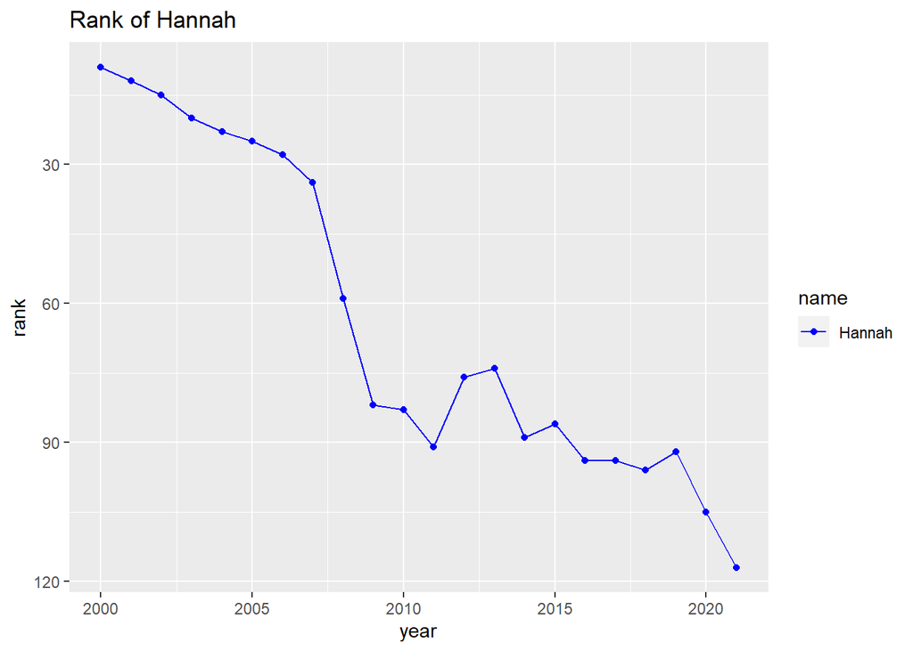

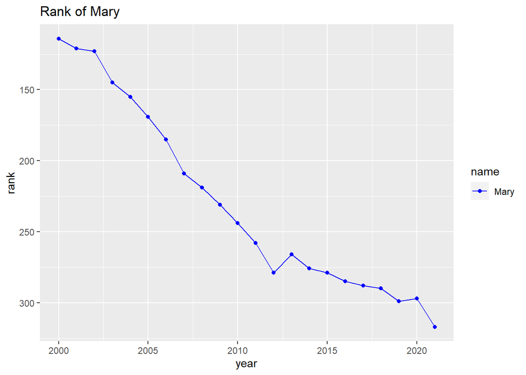

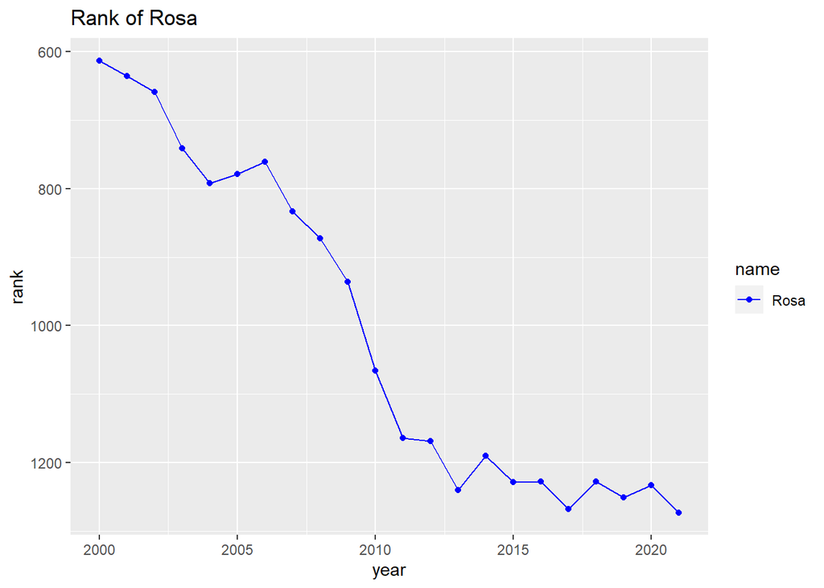

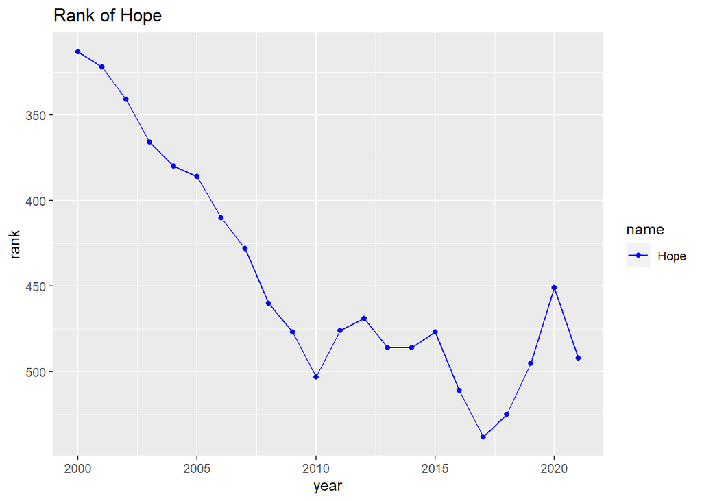

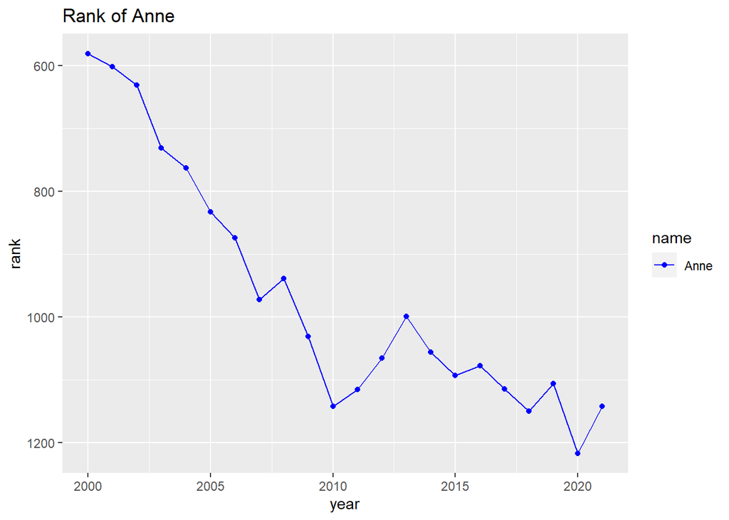

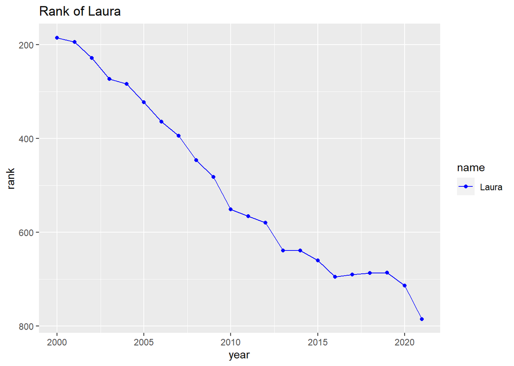

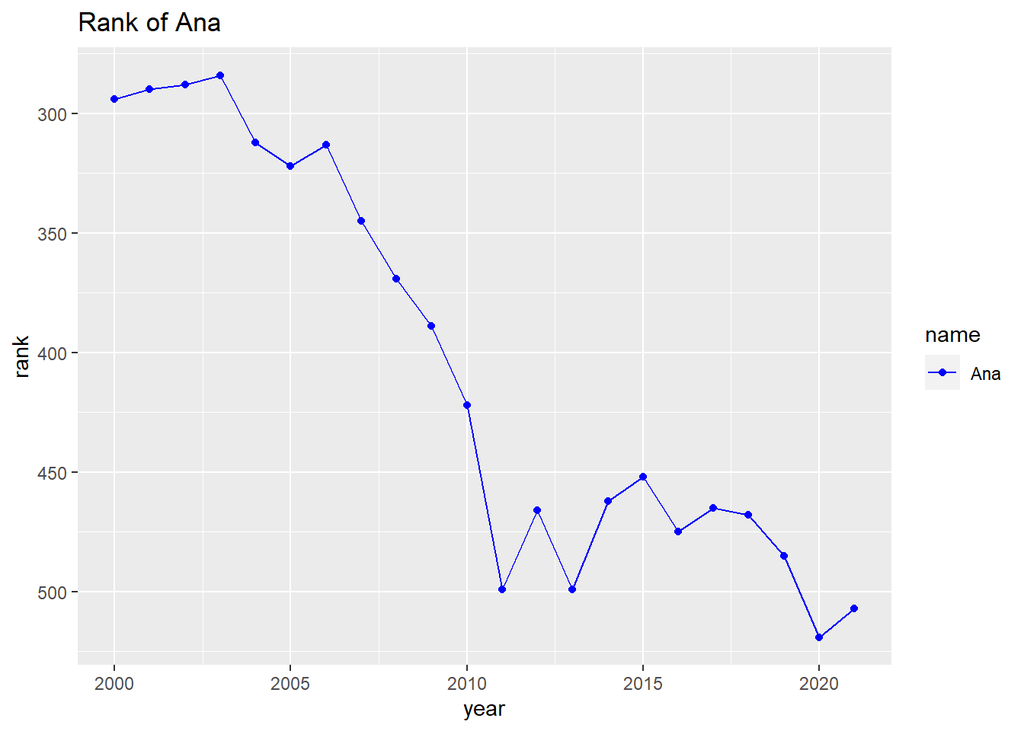

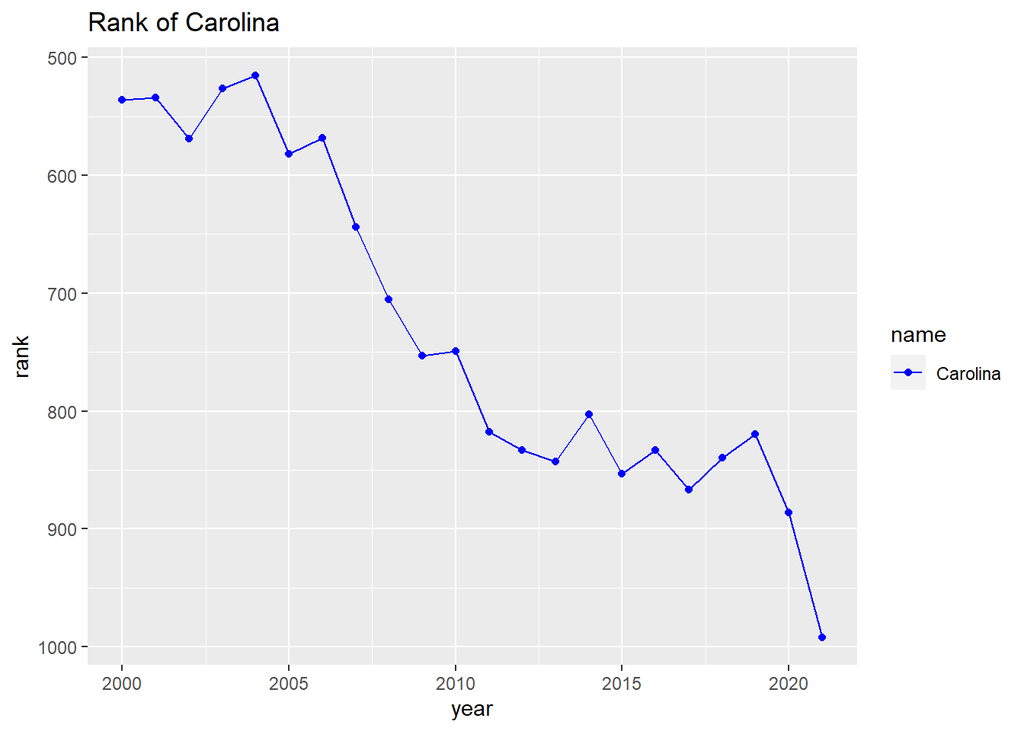

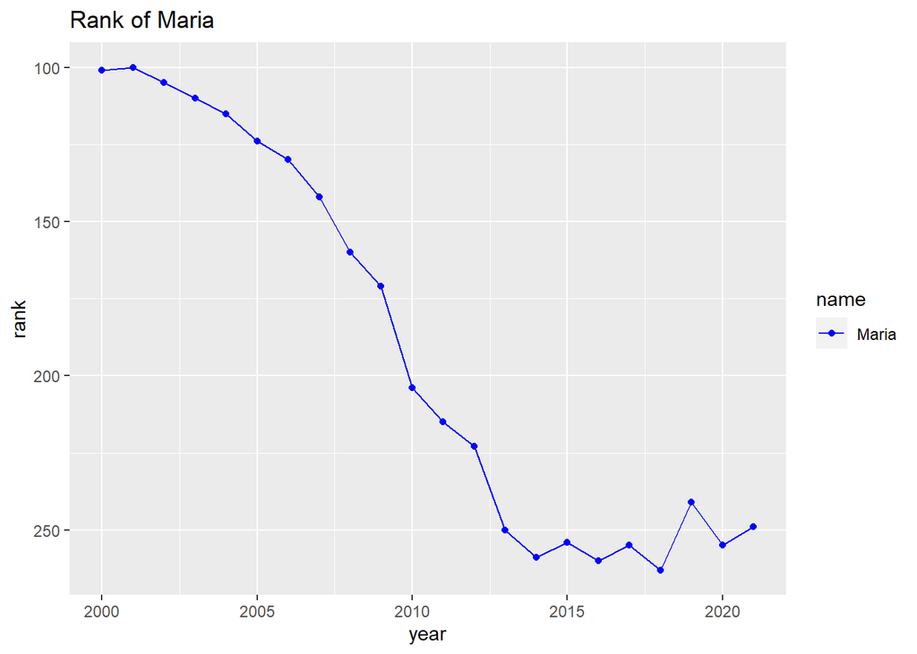

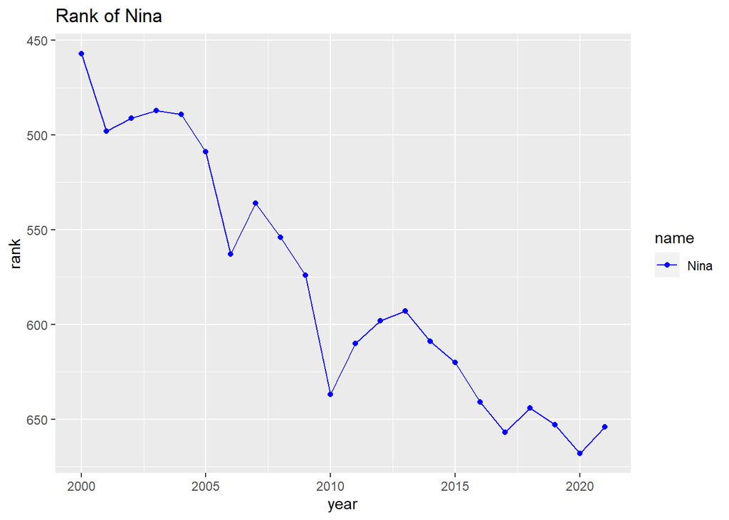

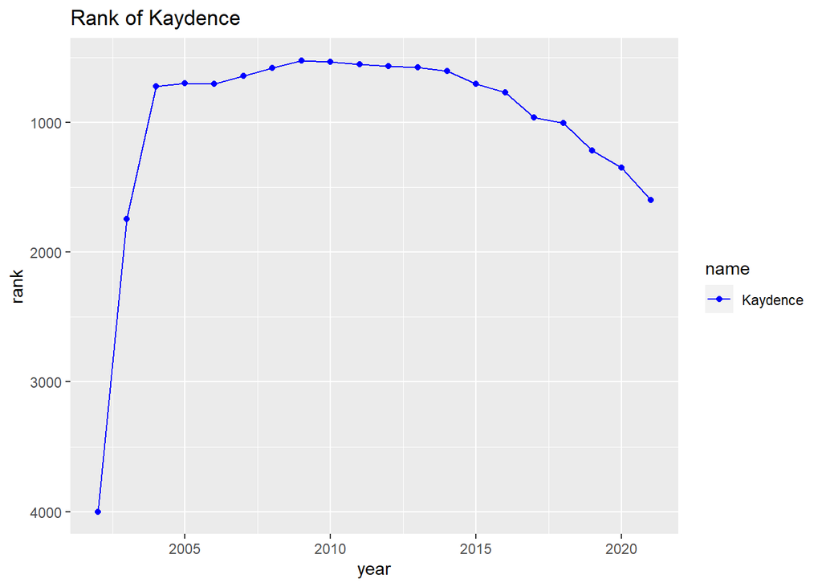

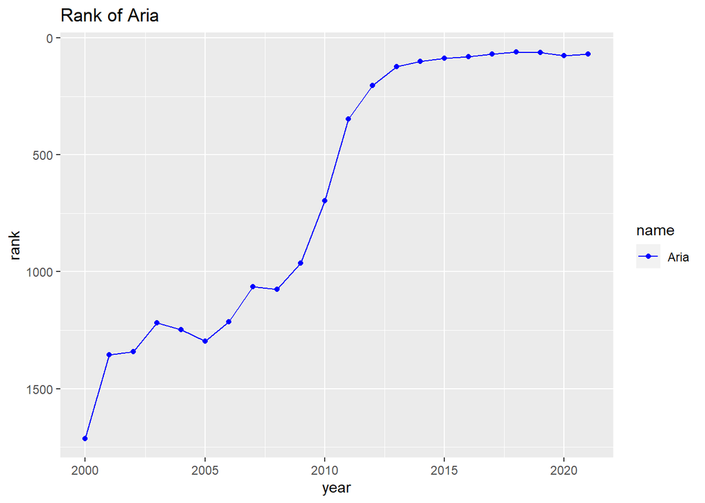

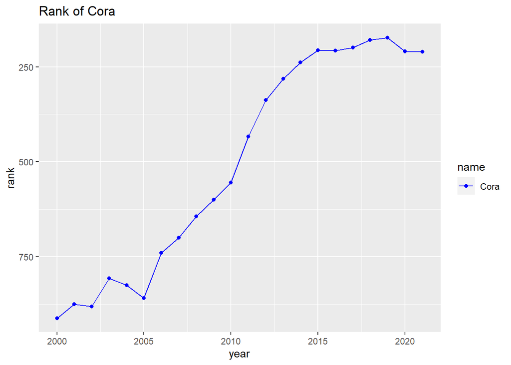

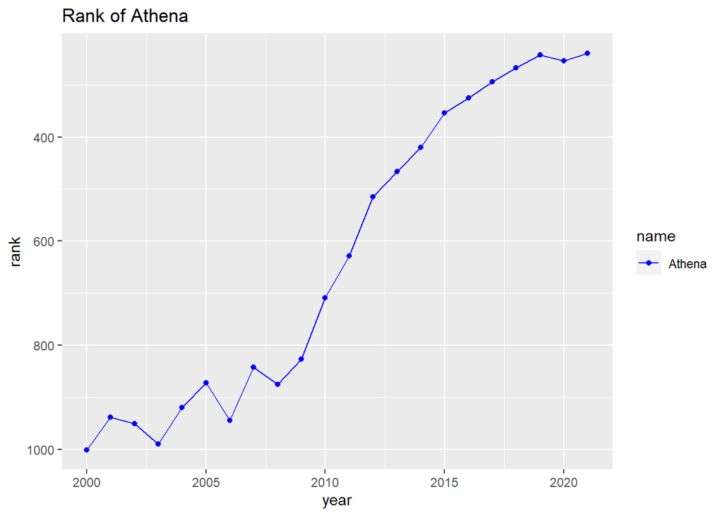

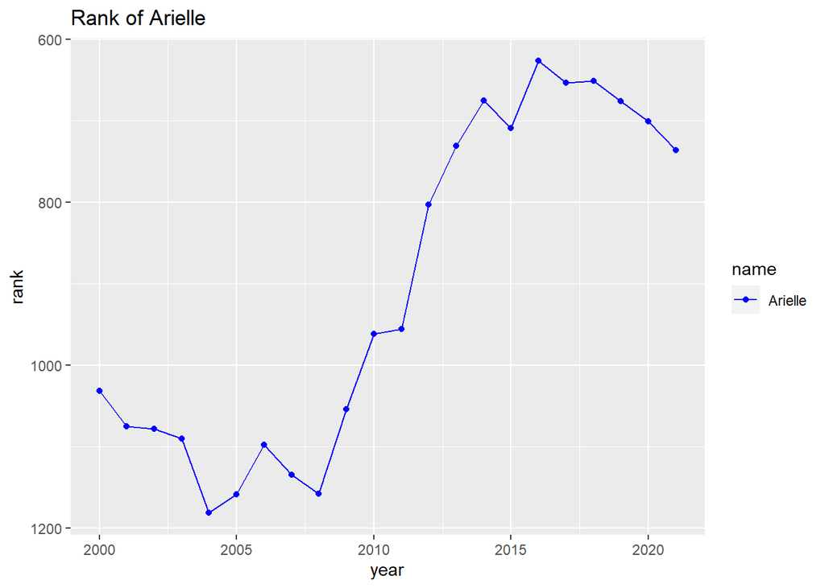

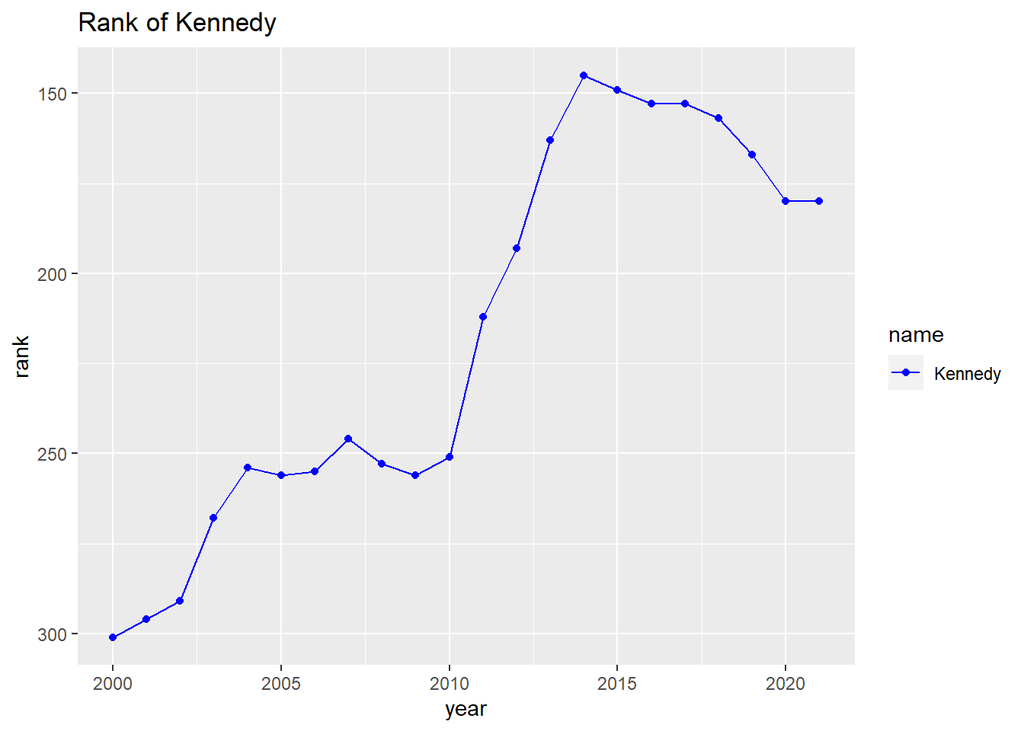

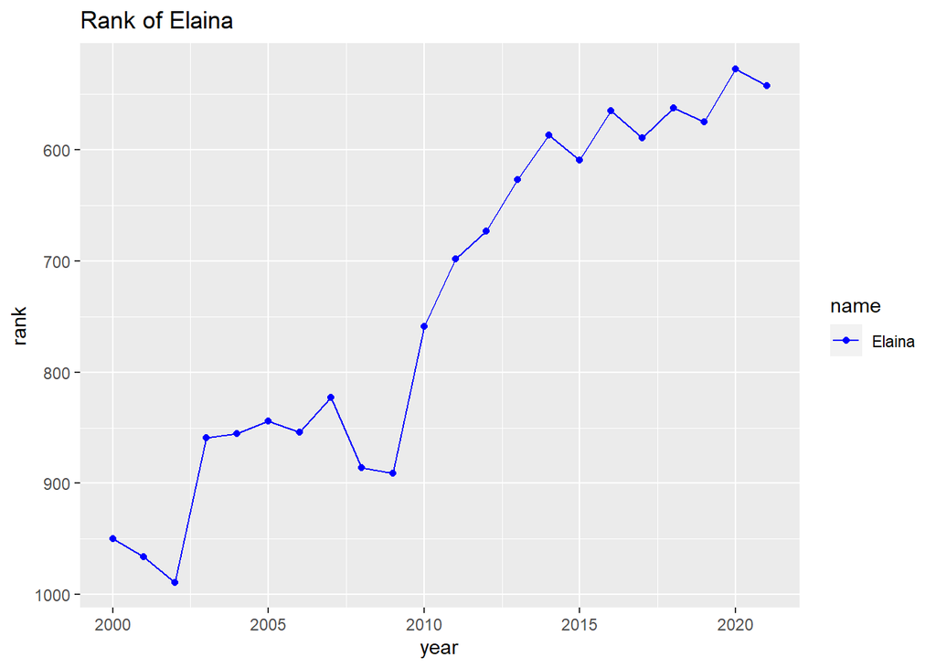

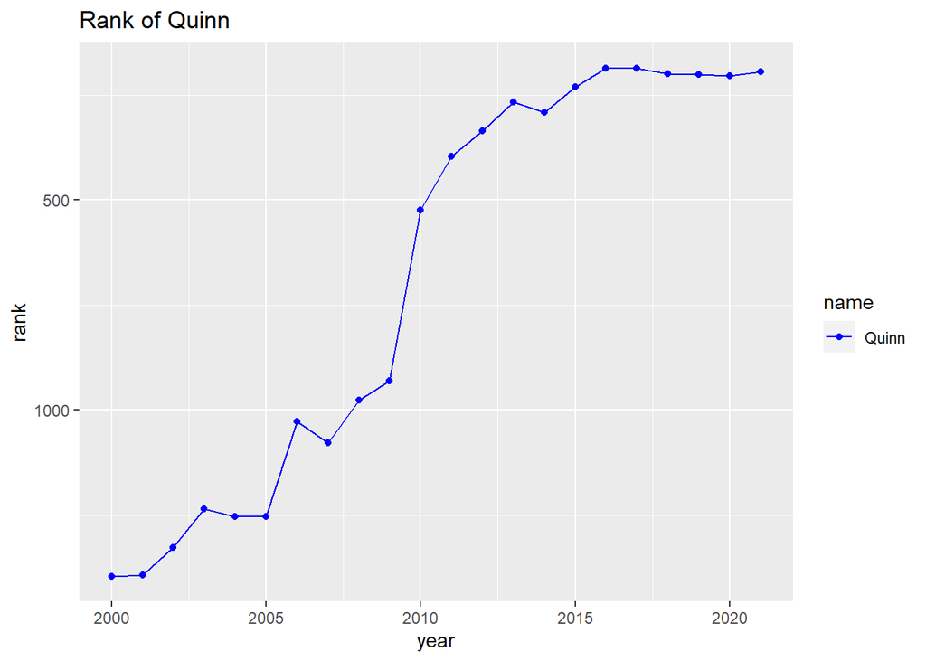

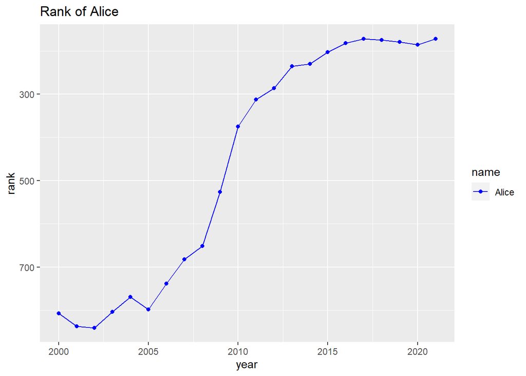

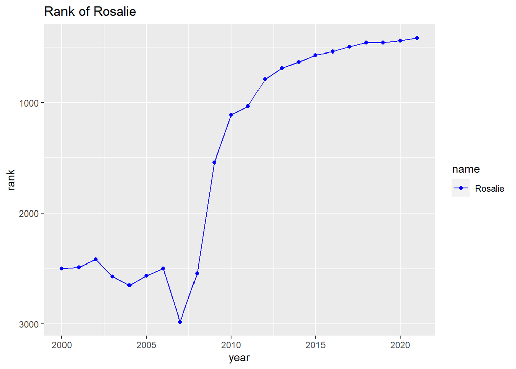

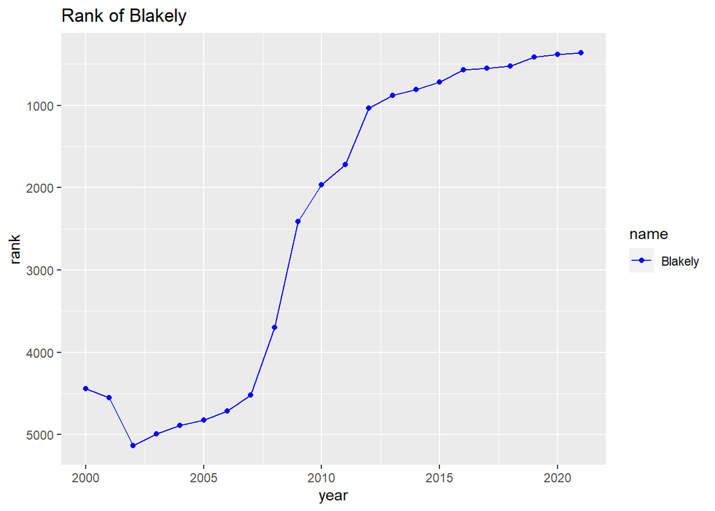

## Act

Now is the time to decide on a name! Parents can change the parameters to run additional reports, perhaps using the full data set or only since their own birth.